# Homework 4

Wei Hern Lim

## Team members

- Michael Mila
- Wei Hern Lim

## Github link:

https://github.com/noahwhlim/lab2

```r
library(tidyverse)
```

```r
library(ggplot2)
```

## Read data

```r
choco <- read.csv("https://ds202-at-isu.github.io/labs/data/choco.csv")
head(choco)
```

```
##    Company Specific.Bean.Origin  REF Review.Date Cocoa.Pct Company.Location
## 1 A. Morin          Agua Grande 1876        2016        63           France
## 2 A. Morin                Kpime 1676        2015        70           France
## 3 A. Morin               Panama 1011        2013        70           France
## 4 A. Morin           Madagascar 1011        2013        70           France
## 5 A. Morin               Brazil 1011        2013        70           France
## 6 A. Morin             Equateur 1011        2013        70           France
##   Rating Bean.Type Broad.Bean.Origin
## 1   3.75                    Sao Tome
## 2   2.75                        Togo
## 3   2.75                      Panama
## 4   3.00   Criollo        Madagascar
## 5   3.25                      Brazil
## 6   3.75                     Ecuador
```

# Question Set I

## 1. What is the overall number of chocolate bars rated?

```r
count(choco)
```

```
##      n
## 1 1852
```

#### Ans: 1852 chocolate bars

## 2. How does the number of ratings depend on the year? Draw a bar chart of the number of reports.

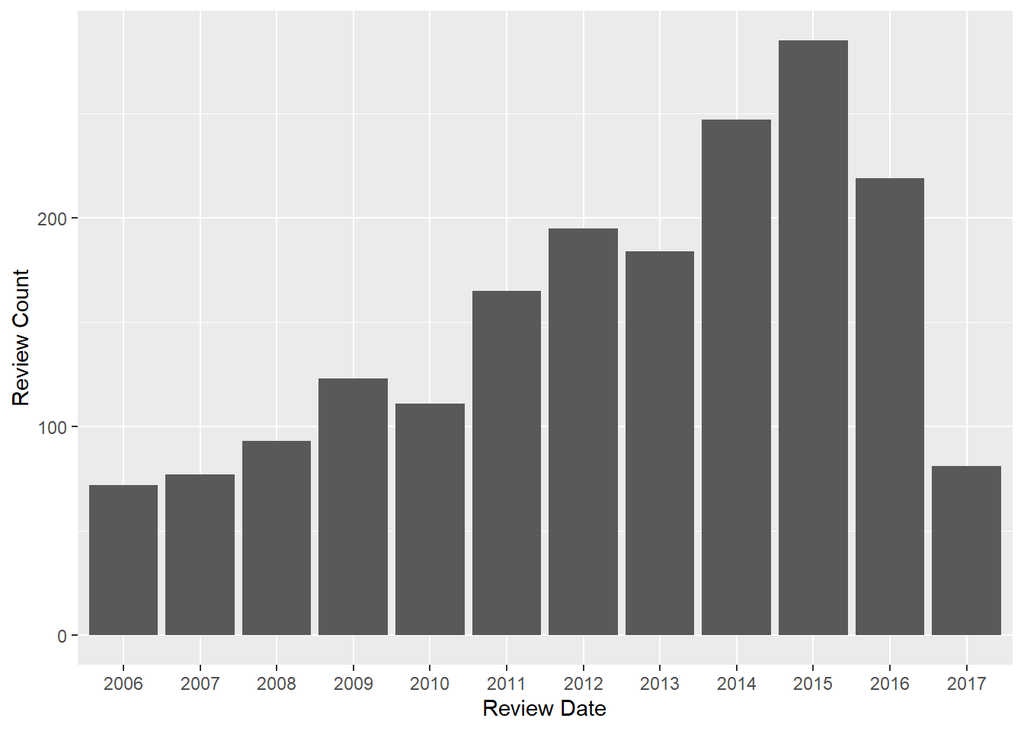

```r
choco %>% ggplot(aes(x = as.factor(Review.Date))) +
  xlab("Review Date") +
  ylab("Review Count") +
  geom_bar()
```

#### Ans: The number of ratings trends upwards from 2006 to 2015 where it starts falling off to about 80 in 2017.

# Question Set II

## 1. How are ratings distributed? Draw a histogram of ratings and describe it. Don’t forget to mention outliers, if there are any.

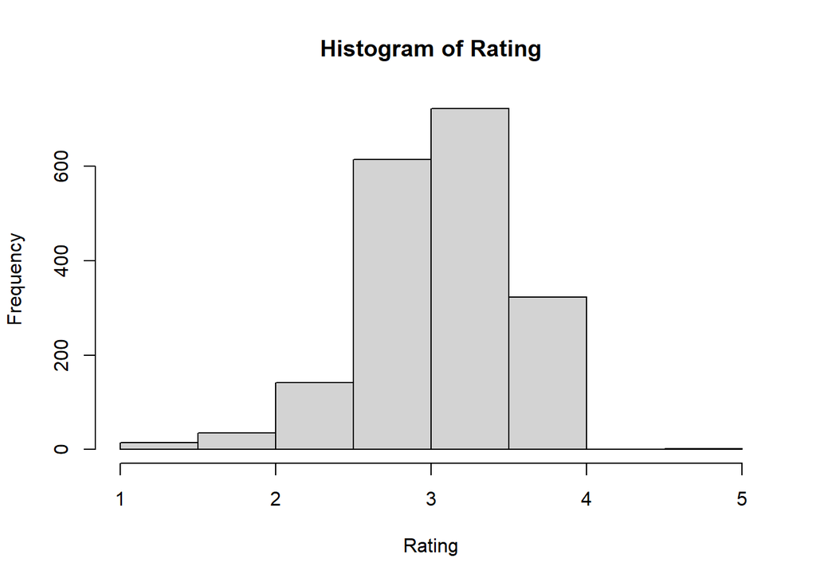

```r
hist(choco$Rating,
     main = "Histogram of Rating",
     xlab = "Rating")
```

#### Ans: The distribution of the ratings are skewed left. There is an outlier where the rating is a 1, and another outlier where the rating is a 5.

## 2. Do ratings depend on the cocoa percentage of a chocolate bar?

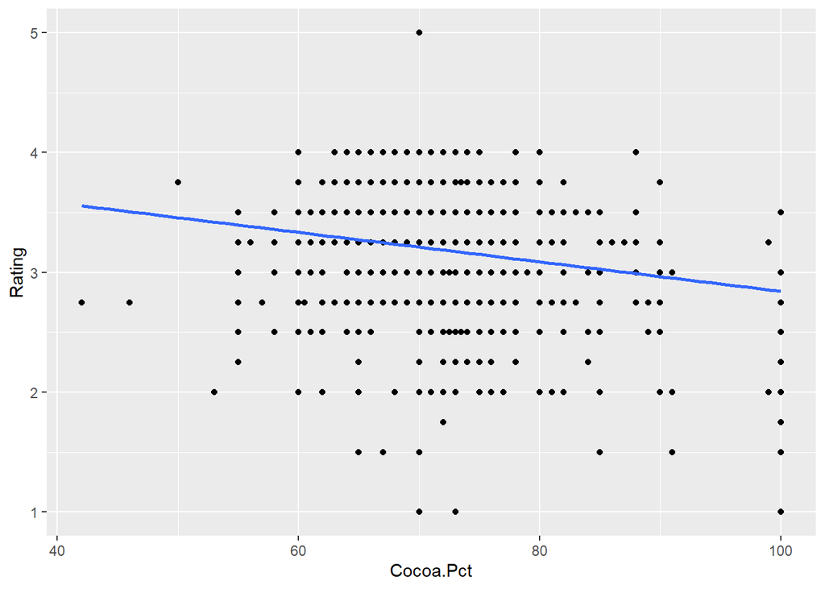

```r
ggplot(choco, aes(x = Cocoa.Pct, y = Rating) ) +
  geom_point() +
  geom_smooth(method = "lm", se = FALSE)
```

#### Ans: Yes, there seems to be a downward trend in ratings as the percentage of cococa present in a chocolate bar increases.

## 3. How do ratings compare across different company locations? Focus on the three locations with the most ratings.

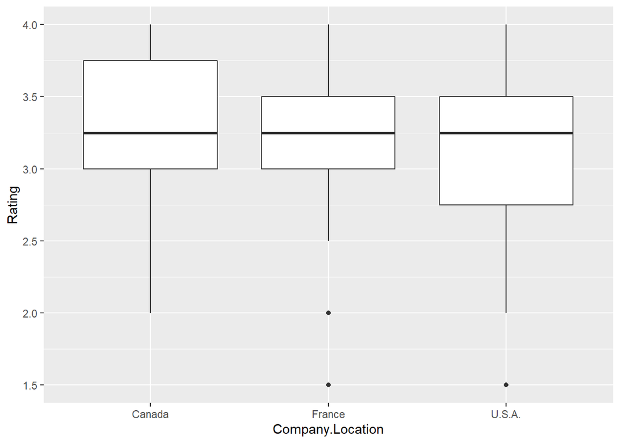

```r
newChoco <- dplyr::filter(choco, Company.Location %in% c("U.S.A.", "France", "Canada"))

ggplot(newChoco, aes(x = Company.Location, y = Rating)) +
  geom_boxplot()
```

#### Ans: They all seem to have the same median rating with Canada and US having a larger variation within them.

## 4. Own Question: What are some statistics about companies in the US?

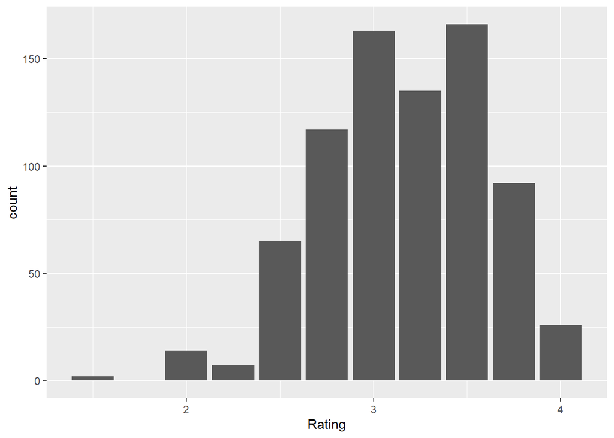

```r
USChoco <- dplyr::filter(choco, Company.Location %in% c("U.S.A."))
ggplot(USChoco, aes(x = Rating)) +
  geom_bar()
```

The ratings of US companies follow closely to all of the companies. The graph shows a left skew.

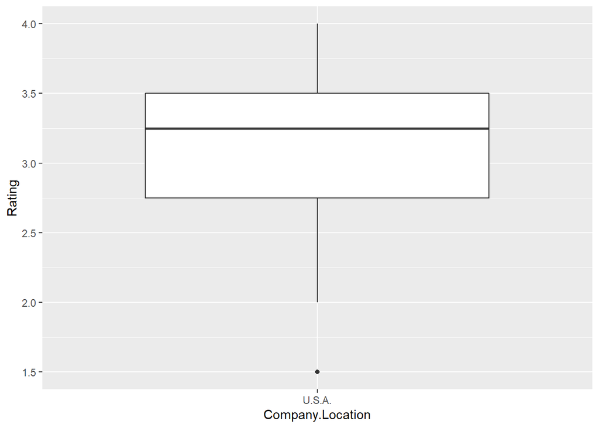

```r
ggplot(USChoco, aes(x = Company.Location, y = Rating)) +
  geom_boxplot()
```

It appears that the median rating is 3.25 for companies in the US. The max value is 4.0. The minimum rating is 1.5. 50% of the companies in the US fall in between a rating of 2.75 and 3.5.

```r
highest_US_companies = levels(reorder(USChoco$Company, USChoco$Rating))[1:10]
highest_US_companies
```

```
##  [1] "Jacque Torres"              "Love Bar"
##  [3] "Shark's"                    "Marsatta"
##  [5] "Cacao Atlanta"              "Chocolate Alchemist-Philly"
##  [7] "Chocovivo"                  "Garden Island"
##  [9] "Lake Champlain (Callebaut)" "Oakland Chocolate Co."
```

## 5. Workflow

Noah worked on question set 2. Michael did the questions for questions set 1. We both worked on the “own question” part together, and used Michael’s computer to push the code for that part. Noah finished his part first, so Michael pulled his code before working on his part. After we completed everything, Michael pushed the final product into the repository.